# Analyse de Co-inertie

Théorie de l’ordination multitableaux et application écologique

Quentin, Inès, Benjamin

2026-10-12

## 1. Données d’étude : Matrice Milieu ($X$)

Dispositif fluvial du Doubs (Verneaux, 1973) — **$n = 30$ stations d’échantillonnage** :

|  | Dist. source (km) | Altitude (m) | Pente (%) | Débit (m³/s) | pH | Oxygène | Nitrates | Phosphates |
| --- | --- | --- | --- | --- | --- | --- | --- | --- |
| Station 1 | 3 | 934 | 6.176 | 84 | 79 | 122 | 20 | 1 |
| Station 2 | 22 | 932 | 3.434 | 100 | 80 | 103 | 20 | 2 |
| Station 3 | 102 | 914 | 3.638 | 180 | 83 | 105 | 22 | 5 |
| Station 4 | 185 | 854 | 3.497 | 253 | 80 | 110 | 21 | 10 |
| Station 5 | 215 | 849 | 3.178 | 264 | 81 | 80 | 52 | 38 |

**Tableau 1a : Matrice $X$ — Descripteurs physico-chimiques et morphologiques (30 × 11)**

- **Nature des variables :** Variables quantitatives continues d’unités hétérogènes (mètres, %, m³/s, mg/L).
- **Ordination préliminaire :** **ACP normée** (standardisation centrée-réduite obligatoire).

## 2. Données d’étude : Matrice Faune ($Y$)

Mesures appariées sur les **$n = 30$ mêmes stations** de la rivière :

|  | Truite | Vairon | Loche | Ombre | Brochet | Brème | Gardon | Tanche |
| --- | --- | --- | --- | --- | --- | --- | --- | --- |
| Station 1 | 3 | 0 | 0 | 0 | 0 | 0 | 0 | 0 |
| Station 2 | 5 | 4 | 3 | 0 | 0 | 0 | 0 | 0 |
| Station 3 | 5 | 5 | 5 | 0 | 1 | 0 | 0 | 0 |
| Station 4 | 4 | 5 | 5 | 0 | 2 | 0 | 0 | 1 |
| Station 5 | 2 | 3 | 2 | 0 | 4 | 0 | 5 | 3 |

**Tableau 1b : Matrice $Y$ — Dénombrements de la communauté ichtyologique (30 × 27)**

- **Nature des variables :** Abondances discrètes en classes d’abondance (0 = absence à 5 = très abondant).
- **Ordination préliminaire :** **ACP centrée** (préservation des abondances relatives entre espèces).

## 3. Du schéma isolé au couplage structural

Deux approches possibles pour relier deux matrices :

**Approches asymétriques**

- **RDA, CCA** (modélisation linéaire)
- Relation directionnelle : $Y = f(X)$
- Expliquer la biologie par le milieu

**Approches symétriques**

- **Co-inertie, Procruste**
- Statut égalitaire des matrices
- Recherche d’une **co-structure**
- **Limite de l’ACP isolée :** Elle explore la variance interne d’une seule matrice sans sonder l’espace conjoint.

## 4. Fondement théorique : La co-inertie

L’analyse de co-inertie (Dolédec & Chessel, 1994) recherche les axes unitaires $u \in \mathbb{R}^p$ et $v \in \mathbb{R}^q$ ($||u||=||v||=1$) maximisant la **covariance projetée** :

$$\max_{u, v} Cov(Xu, Yv)^2$$

$$Cov(Xu, Yv) = \underbrace{\sqrt{Var(Xu)}}_{\text{Inertie } X} \times \underbrace{\sqrt{Var(Yv)}}_{\text{Inertie } Y} \times \underbrace{Corr(Xu, Yv)}_{\text{Corrélation canonique}}$$

- **Compromis d’ordination :** Forte variance dans chaque tableau **et** forte corrélation inter-matrices.

## 5. Protocole calculatoire sous R (`ade4`)

```r
library(ade4)
data(doubs)

# 1. Définition des schémas de dualité (triplets statistiques)
dudi_env <- dudi.pca(doubs$env, scale = TRUE, scannf = FALSE, nf = 2)
dudi_fau <- dudi.pca(doubs$fish, scale = FALSE, scannf = FALSE, nf = 2)

# 2. Diagonalisation de l'opérateur de co-inertie
co_doubs <- coinertia(dudi_env, dudi_fau, scannf = FALSE, nf = 2)
```

**Note**

- **Taux d’inertie Axe 1 :** 88.4% | **Axe 2 :** 10.3%
- **Restitution globale :** Le premier plan factoriel résume **98.7%** de la co-structure totale.

## 6. Espace de compromis : Analyse des résidus

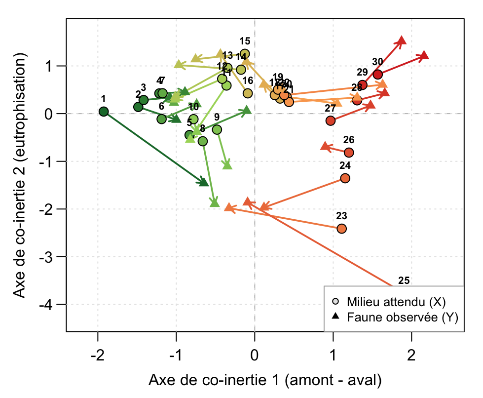

**Figure 1 : Espace de compromis des 30 stations du Doubs**

**Lecture vectorielle**

- **Couleur des points :** Du vert (amont) au rouge (aval) selon les 30 stations.
- **Habillage des symboles :**
  - **● Rond cerclé :** Coordonnées environnementales ($X$).
  - **▲ Triangle :** Coordonnées faunistiques ($Y$).
- **Flèches courtes ($||y_i - x_i|| \approx 0$) :**
  - Accord biotope $\leftrightarrow$ biocénose.
- **Flèches longues (ex: stations 23-25) :**
  - Décalage local (zones altérées / polluées).

## 7. Projection des variables : Espaces $X$ et $Y$

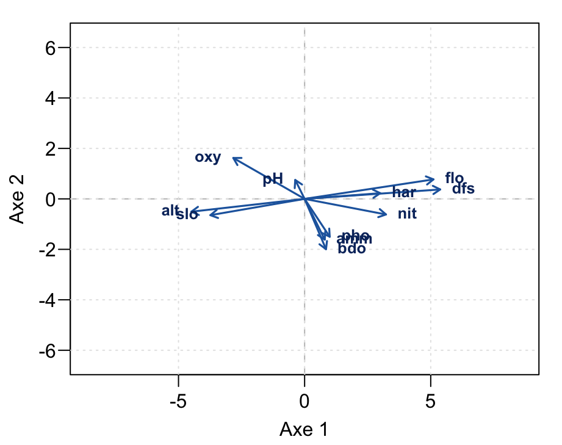

**Figure 2a : Descripteurs abiotiques ($X$)**

- **Pôle amont (gauche) :** Pente (`slo`), altitude (`alt`), oxygène (`oxy`).
- **Pôle aval (droite) :** Débit (`flo`), distance source (`dfs`), nutriments (`nit`, `pho`).

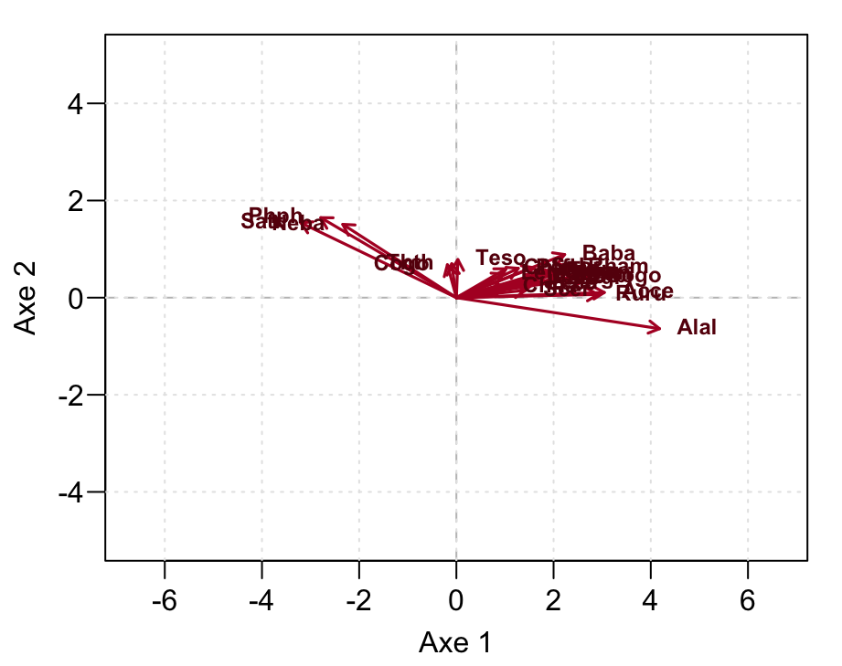

**Figure 2b : Taxons piscicoles ($Y$)**

- **Espèces d’eau vive :** Truite (`Satr`), Vairon (`Phph`), Chabot (`Cogo`).
- **Espèces d’eaux calmes :** Brème (`Abbr`), Gardon (`Ruru`), Tanche (`Titi`).

## 8. Inférence scalaire : Le coefficient RV

Mesure globale d’association matricielle (Robert & Escoufier, 1976) :

$$RV = \frac{\text{Tr}(X X^T Y Y^T)}{\sqrt{\text{Tr}((X X^T)^2) \times \text{Tr}((Y Y^T)^2)}} \in [0, 1]$$

- **Interprétation :** Équivalent multivarié du coefficient de détermination ($R^2$).
- **Propriété géométrique :** Mesure le cosinus de l’angle entre deux configurations de points.
- **Valeur observée pour le Doubs :** **$RV = 0.451$**

## 9. Test de permutation de Monte-Carlo

Test d’hypothèse non paramétrique ($H_0$ : indépendance des deux tableaux) :

```r
set.seed(123)
test_rv <- randtest(co_doubs, nrepet = 999)
cat("RV observé :", round(test_rv$obs, 3), "\n")
cat("P-value    :", test_rv$pvalue, "\n")
```

**Sortie numérique**

```
RV observé : 0.451
```

```
P-value    : 0.001
```

- Rejet franc de $H_0$ ($p = 0.001$).
- La co-structure observée n’est pas fortuite.

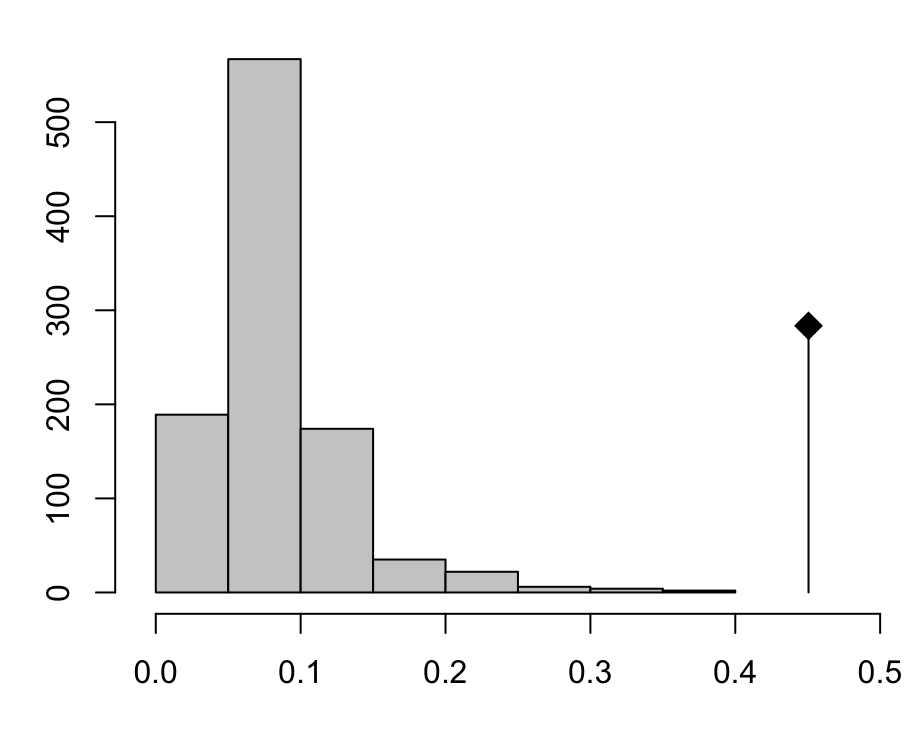

**Figure 3 : Distribution de randomisation sous $H_0$**

## 10. Comparatif visuel : AFM vs Co-inertie

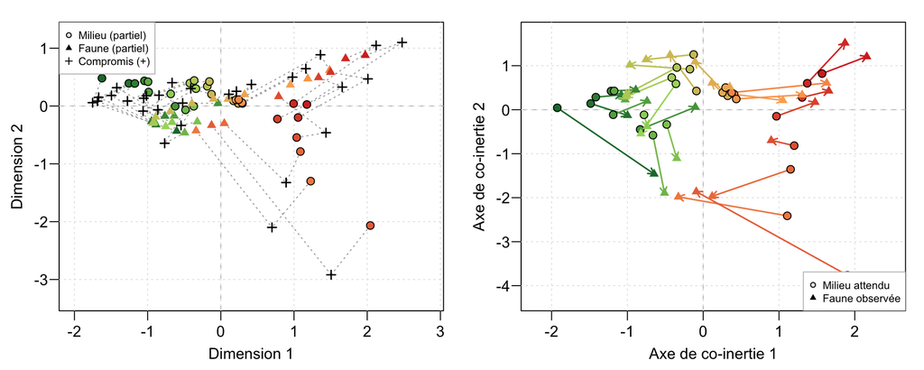

**Figure 4a : AFM (synthèse par barycentre)**

- **Objectif :** Résumer un compromis moyen entre tableaux.
- **Limite :** Les écarts sont amortis par la projection vers le centre moyen (effet d’atténuation).

**Figure 4b : Co-inertie (couplage vectoriel direct)**

- **Objectif :** Maximiser la covariance croisée directe ($X \leftrightarrow Y$).
- **Force :** Isole directement l’amplitude et le sens du découplage écologique station par station.

## 11. Propriétés métriques & Précautions

**Atouts méthodologiques**

- **Condition $p + q > n$ :** Opère sans saturation en grande dimension (omiques, microbiome).
- **Pas d’inversion matricielle :** Insensible à la multicolinéarité stricte.
- **Universalité :** Couple ACP, AFC, ACM ou PCoA via les triplets statistiques.

**Précautions d’usage**

- **Descriptif :** Pas de modèle prédictif directionnel direct ($Y \neq f(X)$).
- **Sensibilité :** Vulnérable aux points aberrants à forte inertie (*outliers*).

## 12. Synthèse épistémologique

- **Dualité théorique :** Compromis optimal entre inertie interne et corrélation canonique.
- **Outil diagnostique :** Le plan de compromis isole visuellement les consensus écologiques et les anomalies locales (résidus).
- **Robustesse statistique :** Validation non paramétrique par le coefficient $RV$ et test de permutations.